# Tutorial for the cohetsurr package

If you are viewing the html version of this tutorial, you can find the R markdown file here: https://github.com/rebeccaknowlton/cohetsurr. It is the file called cohetsurr_tutorial.Rmd. In this tutorial we will go through examples using the main functions in the **cohetsurr** R package which can be installed from CRAN. The **ggplot2** package also needs to be installed from CRAN (to go through this tutorial) as we will use it to visualize the results. Then, load the packages as follows:

```r
# set seed for reproducibility
set.seed(1)
# load package
library(cohetsurr)
library(ggplot2)
```

The **cohetsurr** package provides functions to assess and test for complex heterogeneity in the strength of a surrogate marker with respect to multiple baseline covariates in either a randomized treatment setting or observational setting. For a randomized treatment setting, the functions assess and test for heterogeneity using both a parametric model and a semiparametric two-step model. For an observational setting, functions in this package assess complex heterogeneity in the strength of a surrogate marker using meta-learners, with options for different base learners. We will start with the randomized setting, and then move on to the observational setting.

## Randomized Treatment Setting

The package includes a hypothetical example dataset which contains 1000 observations from a treatment group and 1000 observations from a control group, where treatment assignment is randomized. Let’s take a look at the data:

```r
data(exampledata)
names(exampledata)
```

```
## [1] "y"       "s"       "a"       "w1"      "w2"      "w1.grid" "w2.grid"
```

Within the dataset, **y** denotes the primary outcome, **s** denotes the surrogate marker, **a** denotes the randomized treatment assignment where 1 indicates treatment and 0 indicates control, **w1** is a baseline covariate, and **w2** is a second baseline covariate (we do not need **w1.grid** or **w2.grid** for this illustration).

The main function for the randomized setting is **complex.heterogeneity** which assesses complex heterogeneity in the strength of a surrogate marker by estimating the proportion of the treatment effect explained (PTE) by the surrogate marker as a function of multiple baseline covariates. Optionally, the function will test for evidence of heterogeneity overall and can flag regions where the proportion of treatment effect explained is above a given threshold. The required arguments are **y** which is the primary outcome, **s** which is the surrogate marker, **a** which is the treatment indicator, and **W.mat** which is the matrix of baseline covariates. Let’s take a look:

```r
cohet = complex.heterogeneity(y = exampledata$y, s = exampledata$s,
    a = exampledata$a, W.mat = matrix(cbind(exampledata$w1, exampledata$w2),
        ncol = 2))
names(cohet)
```

```
## [1] "return.grid"
```

```r
cohet$return.grid
```

```
##      W.grid             delta   delta.s       R.s
## 1  1.291413 1.206980 38.94409  3.332990 0.9144160
## 2  2.481757 1.206980 40.77567  5.164570 0.8733419
## 3  3.672101 1.206980 42.60725  6.996150 0.8357991
## 4  4.862445 1.206980 44.43883  8.827730 0.8013510
## 5  1.291413 2.390034 40.71041  5.099311 0.8747418
## 6  2.481757 2.390034 42.54199  6.930891 0.8370812
## 7  3.672101 2.390034 44.37357  8.762471 0.8025295
## 8  4.862445 2.390034 46.20515 10.594050 0.7707171
## 9  1.291413 3.573087 42.47673  6.865632 0.8383672
## 10 2.481757 3.573087 44.30831  8.697211 0.8037115
## 11 3.672101 3.573087 46.13989 10.528791 0.7718072
## 12 4.862445 3.573087 47.97147 12.360371 0.7423391
## 13 1.291413 4.756141 44.24305  8.631952 0.8048970
## 14 2.481757 4.756141 46.07463 10.463532 0.7729004
## 15 3.672101 4.756141 47.90621 12.295112 0.7433504
## 16 4.862445 4.756141 49.73779 14.126691 0.7159767
```

The function will estimate the PTE on a grid of **W.mat**, specified by the argument **W.grid**; if this is not provided by the user, the default is created using a grid of 4 equally spaced points for each baseline covariate. In the example above, we do not provide a grid and thus a grid is made as described resulting in 16 grid points where PTE is estimated. The returned **return.grid** shows the grid points in the first two columns, and the estimates of the treatment effect on the primary outcome, **delta**, the residual treatment effect, **delta.s**, and the PTE, **R.s**. Note that values of **R.s** close to 1 indicate a strong surrogate while values close to 0 indicate a weak surrogate. We can visualize these results using a heatmap:

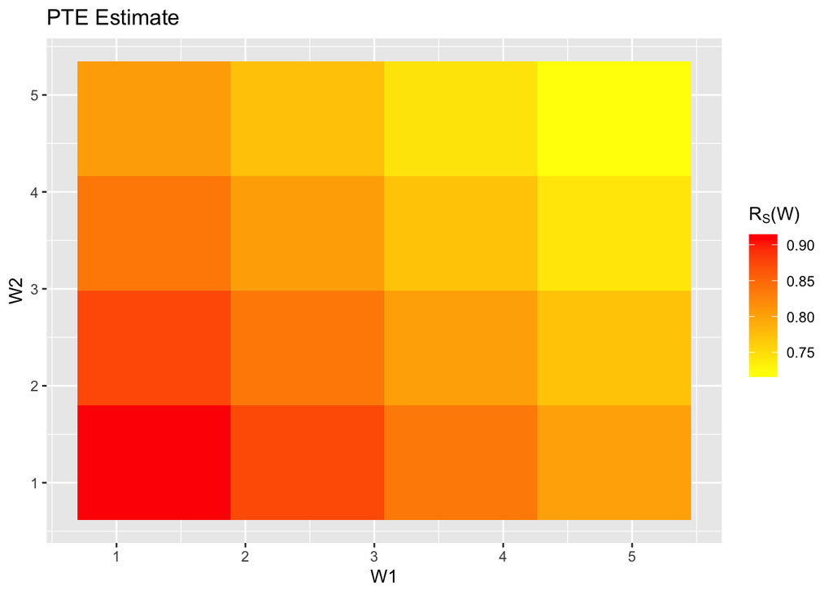

```r
# rename first two columns
data.for.plot = cohet$return.grid
names(data.for.plot)[1:2] = c("W1", "W2")
# create plot

ggplot(data.for.plot, aes(W1, W2, fill = R.s)) + geom_tile() +
    scale_fill_gradient(low = "yellow", high = "red", limits = c(min(data.for.plot$R.s),
        max(data.for.plot$R.s))) + xlab("W1") + ylab("W2") +
    labs(fill = expression(paste(R[S], "(W)", sep = "")), title = "PTE Estimate")
```

To request the formal test for heterogeneity, use **test=TRUE**; to request variance estimates, use **variance=TRUE**. Variance estimation is done via the bootstrap and thus, can be computationally intensive.

```r
# with test and variance estimation
cohet = complex.heterogeneity(y = exampledata$y, s = exampledata$s,
    a = exampledata$a, W.mat = matrix(cbind(exampledata$w1, exampledata$w2),
        ncol = 2), test = TRUE, var = TRUE)
names(cohet)
```

```
## [1] "return.grid" "pval"
```

```r
names(cohet$return.grid)
```

```
##  [1] "W.grid"        ""              "delta"         "delta.s"
##  [5] "R.s"           "delta.var"     "delta.s.var"   "R.s.var"
##  [9] "delta.lower"   "delta.upper"   "delta.s.lower" "delta.s.upper"
## [13] "R.s.lower"     "R.s.upper"
```

```r
cohet$pval
```

```
## [1] 3.341227e-149
```

Notice that **return.grid** now includes variance estimates and confidence interval bounds. The p-value for the heterogeneity test is significant thus indicating that there is evidence of heterogeneity in the surrogate strength with respect to these two baseline covariates.

By default, the function will employ parametric estimation; this can be changed by specifying **type=“two step”** for two-step semiparametric estimation or **type=“both”** for both estimates. As shown above, the resulting estimates can be visualized using a heatmap. The test and variance estimates can also be requested as above; this will be computationally intensive because it involves both kernel smoothing and bootstrapping, and the computation time will grow as the grid size increases.

```r
# now with two-step semiparametric estimation
cohet = complex.heterogeneity(y = exampledata$y, s = exampledata$s,
    a = exampledata$a, W.mat = matrix(cbind(exampledata$w1, exampledata$w2),
        ncol = 2), type = "two step")
names(cohet)
```

```
## [1] "return.grid"
```

```r
cohet$return.grid
```

```
##      W.grid               U.hat delta.two.step delta.s.two.step R.s.two.step
## 1  1.291413 1.206980 -1.8365047       47.91654         4.574457    0.9045328
## 2  2.481757 1.206980 -1.4235928       34.80155         6.145788    0.8234048
## 3  3.672101 1.206980 -1.0106809       42.74139         7.604713    0.8220761
## 4  4.862445 1.206980 -0.5977689       46.19011         8.156428    0.8234161
## 5  1.291413 2.390034 -1.0208948       42.76299         7.537875    0.8237290
## 6  2.481757 2.390034 -0.6079828       46.16004         8.147615    0.8234920
## 7  3.672101 2.390034 -0.1950709       46.27546         8.126109    0.8243970
## 8  4.862445 2.390034  0.2178410       47.46843         9.958345    0.7902112
## 9  1.291413 3.573087 -0.2052848       46.01718         8.097251    0.8240385
## 10 2.481757 3.573087  0.2076271       47.75588        10.002557    0.7905482
## 11 3.672101 3.573087  0.6205391       44.69184        11.093089    0.7517872
## 12 4.862445 3.573087  1.0334510       44.06505        11.304082    0.7434683
## 13 1.291413 4.756141  0.6103251       44.99172        11.026097    0.7549306
## 14 2.481757 4.756141  1.0232371       43.84140        11.274246    0.7428402
## 15 3.672101 4.756141  1.4361490       41.77600        12.609328    0.6981681
## 16 4.862445 4.756141  1.8490610       49.83144        12.714038    0.7448591
```

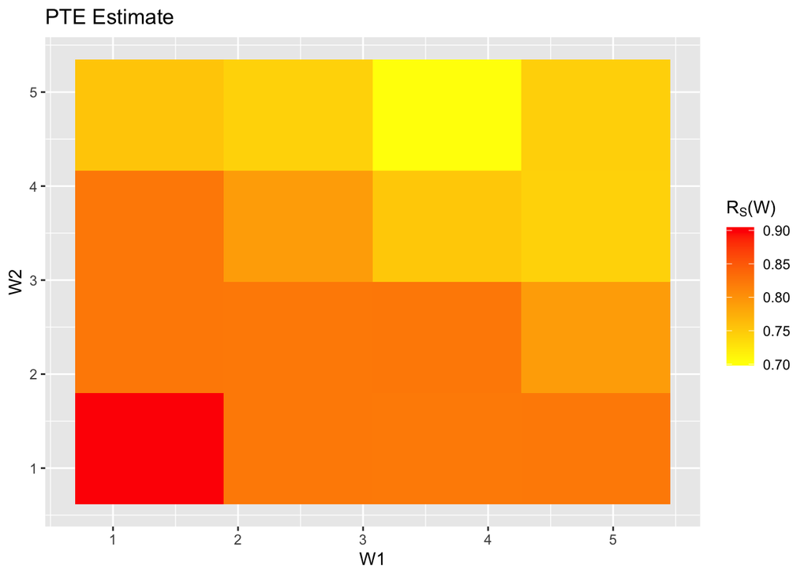

```r
# rename first two columns
data.for.plot = cohet$return.grid
names(data.for.plot)[1:2] = c("W1", "W2")

# create plot
ggplot(data.for.plot, aes(W1, W2, fill = R.s.two.step)) + geom_tile() +
    scale_fill_gradient(low = "yellow", high = "red", limits = c(min(data.for.plot$R.s),
        max(data.for.plot$R.s))) + xlab("W1") + ylab("W2") +
    labs(fill = expression(paste(R[S], "(W)", sep = "")), title = "PTE Estimate")
```

```r
# with test and variance estimation
cohet = complex.heterogeneity(y = exampledata$y, s = exampledata$s,
    a = exampledata$a, W.mat = matrix(cbind(exampledata$w1, exampledata$w2),
        ncol = 2), type = "two step", test = TRUE, var = TRUE)
cohet$pval
```

```
## [1] 0.001
```

Here, the p-value for the heterogeneity test based on the semiparametric estimate is significant, thus indicating that there is evidence of heterogeneity in the surrogate strength with respect to these two baseline covariates.

Lastly, the **threshold** argument within the function can be used to flag regions of covariate space where the estimate PTE is at least that high. For example, if **threshold=0.75** the function will implement procedures to flag which regions of the **W.grid** have a PTE equal to 0.75 or higher. Again, this will be computationally intensive. This can be visualized with a tile plot as illustrated below, where red indicates that the PTE is identified to be greater than or equal to the threshold for that gridpoint, and grey indicates it is less than the threshold.

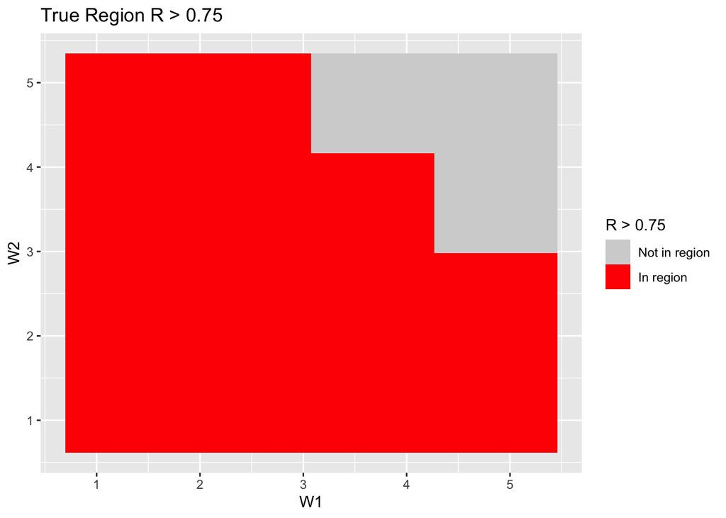

```r
cohet = complex.heterogeneity(y = exampledata$y, s = exampledata$s,
    a = exampledata$a, W.mat = matrix(cbind(exampledata$w1, exampledata$w2),
        ncol = 2), test = TRUE, var = TRUE, threshold = 0.75)

# rename first two columns
data.for.plot = cohet$return.grid
names(data.for.plot)[1:2] = c("W1", "W2")
data.for.plot$threshold.flag = as.factor(data.for.plot$threshold.flag)

# create plot
ggplot(data.for.plot, aes(W1, W2, fill = threshold.flag)) + geom_tile() +
    xlab("W1") + ylab("W2") + scale_fill_manual(breaks = c("0",
    "1"), values = c("light grey", "red"), labels = c("Not in region",
    "In region")) + labs(fill = "R > 0.75", title = "True Region R > 0.75")
```

## Non-Randomized Treatment Setting

We now move on to the non-randomized i.e. observational setting. In the observational setting, the user must specify a training and testing set of data. All this means is that you should take your dataset and randomly split it into a training set and a test set, for example 90% and 10%, respectively. Again, the package includes example hypothetical datasets that we will use for illustration.

```r
data(obs_exampledata_train)
head(obs_exampledata_train)
```

```
##          X1       X2       X3       X4        X5         X6 G        S
## 1 0.9232983 6.291101 4.971358 5.686364 1.1422287 0.27613782 1 5.940506
## 2 0.7730175 6.590360 1.716362 3.236232 1.7853075 0.10394207 0 2.759727
## 3 1.6569673 4.611686 3.683708 5.013336 0.4553728 0.86465245 1 3.193464
## 4 0.1691495 6.215147 2.966535 2.177326 0.7526553 0.38369394 0 3.349144
## 5 1.4056479 6.430210 2.615342 6.052838 1.9398118 0.77807732 1 5.899278
## 6 1.4513122 5.151352 4.108125 2.599876 1.5024203 0.02206257 0 3.412703
##           Y
## 1 20.226228
## 2  9.820111
## 3 14.804049
## 4 10.582793
## 5 21.271163
## 6 12.229968
```

```r
data(obs_exampledata_test)
head(obs_exampledata_test)
```

```
##              X1        X2         X3       X4        X5         X6 G        S
## 1095 0.96565375  3.267125 0.93314238 4.184719 0.9114749 0.02557413 1 6.907892
## 461  2.01248807  5.781385 3.76757635 1.087923 0.3121258 2.80640872 1 8.522094
## 220  0.10828633  8.533154 0.09635215 1.774433 0.8221123 2.48943533 0 2.750959
## 1712 0.04377545  2.185866 3.56016022 2.058921 1.4494977 0.42045170 1 5.633402
## 1628 2.26630352  3.010368 3.07654996 2.261247 0.2939175 0.89544278 1 7.032053
## 1479 2.58063923 13.572497 3.56570963 1.799847 0.8643863 0.58193807 0 4.661351
##             Y
## 1095 20.60940
## 461  28.46752
## 220  10.85154
## 1712 14.61840
## 1628 24.04923
## 1479 19.61071
```

The example training set has 1800 observations, and the example testing set has 200 observations. The covariates **X1** through **X6** are baseline covariates that may be confounders associated with treatment assignment. In these datasets, **G** denotes the treatment group (where a value of 1 indicates the treatment group, and 0 indicates the control group); **S** denotes the surrogate marker; and **Y** denotes the primary outcome.

The main function for observational data is **obs.het.surr**, which (similar to the randomized setting) assesses complex heterogeneity in the strength of a surrogate marker by estimating the proportion of the treatment effect explained (PTE) by the surrogate marker as a function of the baseline covariates. The required arguments are **df.train**, the dataframe containing training data; **df.test**, the dataframe containing testing data; and **type**, the type of base learners to use. Your options for the base learners are “linear”, “gam”, “trees”, or “all” (which means all 3 learners are implemented). The dataframes are required to have columns named **G**, **S**, and **Y**. Any remaining columns will be taken as the baseline covariates. Let’s take a look, using linear base learners:

```r
obshet = obs.het.surr(df.train = obs_exampledata_train, df.test = obs_exampledata_test,
    type = "linear")
head(obshet)
```

```
##              X1        X2         X3       X4        X5         X6 G        S
## 1095 0.96565375  3.267125 0.93314238 4.184719 0.9114749 0.02557413 1 6.907892
## 461  2.01248807  5.781385 3.76757635 1.087923 0.3121258 2.80640872 1 8.522094
## 220  0.10828633  8.533154 0.09635215 1.774433 0.8221123 2.48943533 0 2.750959
## 1712 0.04377545  2.185866 3.56016022 2.058921 1.4494977 0.42045170 1 5.633402
## 1628 2.26630352  3.010368 3.07654996 2.261247 0.2939175 0.89544278 1 7.032053
## 1479 2.58063923 13.572497 3.56570963 1.799847 0.8643863 0.58193807 0 4.661351
##             Y     delta  delta.s       R.s
## 1095 20.60940  6.260396 2.998991 0.5209582
## 461  28.46752  7.564392 4.918347 0.3498027
## 220  10.85154  3.901074 1.365548 0.6499558
## 1712 14.61840  3.885881 1.220593 0.6858903
## 1628 24.04923  8.610251 5.427267 0.3696737
## 1479 19.61071 10.071615 6.310869 0.3734005
```

Notice how the function returns the **df.test** dataframe back to you, but with columns appended which are the individual-level estimates of the treatment effect on the primary outcome, **delta**; the residual treatment effect, **delta.s**; and the PTE, **R.s**. We can examine how the estimated PTE for individuals in the testing set varies using a simple histogram and a five number summary:

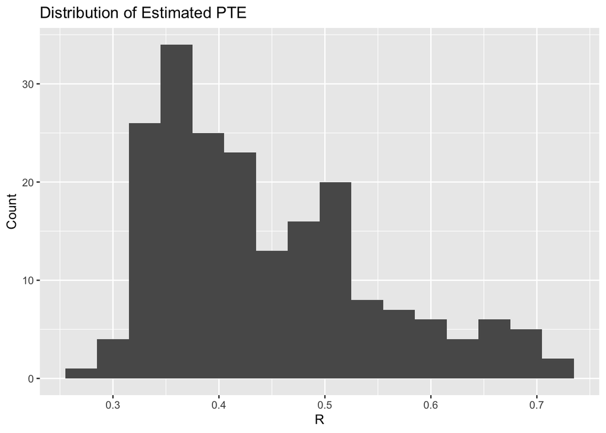

```r
ggplot(obshet) + geom_histogram(aes(R.s), binwidth = 0.03) +
    xlab("R") + ylab("Count") + labs(title = "Distribution of Estimated PTE")
```

```r
fivenum(obshet$R.s)
```

```
## [1] 0.2774658 0.3648660 0.4181227 0.5044769 0.7075918
```

To request variance estimates and confidence intervals, use **var.want = TRUE**. Variance estimation is done via the bootstrap, and thus can be computationally intensive. For example, we can request GAM base learners with variance estimates:

```r
obshet = obs.het.surr(df.train = obs_exampledata_train, df.test = obs_exampledata_test,
    type = "gam", var.want = TRUE)
head(obshet)
```

```
##              X1        X2         X3       X4        X5         X6 G        S
## 1095 0.96565375  3.267125 0.93314238 4.184719 0.9114749 0.02557413 1 6.907892
## 461  2.01248807  5.781385 3.76757635 1.087923 0.3121258 2.80640872 1 8.522094
## 220  0.10828633  8.533154 0.09635215 1.774433 0.8221123 2.48943533 0 2.750959
## 1712 0.04377545  2.185866 3.56016022 2.058921 1.4494977 0.42045170 1 5.633402
## 1628 2.26630352  3.010368 3.07654996 2.261247 0.2939175 0.89544278 1 7.032053
## 1479 2.58063923 13.572497 3.56570963 1.799847 0.8643863 0.58193807 0 4.661351
##             Y     delta   delta.s       R.s delta.var delta.s.var     R.s.var
## 1095 20.60940  6.930140 3.0975764 0.5530283 0.1329934  0.06507914 0.001431370
## 461  28.46752  7.673185 4.9209925 0.3586767 0.2585536  0.09041826 0.002299245
## 220  10.85154  4.126239 1.1824696 0.7134268 0.3305124  0.17293556 0.006966014
## 1712 14.61840  3.303303 0.9903417 0.7001965 0.2108333  0.06477309 0.008139712
## 1628 24.04923  8.730260 5.4244374 0.3786626 0.1587754  0.05305323 0.001413939
## 1479 19.61071 10.368065 6.2042810 0.4015970 0.4485171  0.26291294 0.002152131
##      delta.lower delta.upper delta.s.lower delta.s.upper R.s.lower R.s.upper
## 1095    6.246778    7.761712     2.5066326      3.514577 0.4969156 0.6374533
## 461     6.508063    8.411952     4.4462725      5.584783 0.2269336 0.4139179
## 220     2.764041    5.404138     0.4784029      2.103481 0.4539934 0.8532764
## 1712    2.253027    3.981727     0.6651114      1.774071 0.3769257 0.7664972
## 1628    7.816244    9.315684     4.8628178      5.856462 0.2920949 0.4259803
## 1479    9.203095   11.283157     4.6243720      6.669763 0.3364992 0.5280425
```

Additionally, users can specify a **threshold** argument, which tests whether individuals in the testing set have a PTE greater than the threshold. Since testing is done using bootstrap iterations, we must also specify **var.want = TRUE**. For example, we can identify individuals for whom the estimated PTE is 0.5 or higher:

```r
obshet = obs.het.surr(df.train = obs_exampledata_train, df.test = obs_exampledata_test,
    type = "linear", var.want = TRUE, threshold = 0.5)
head(obshet)
```

```
##              X1        X2         X3       X4        X5         X6 G        S
## 1095 0.96565375  3.267125 0.93314238 4.184719 0.9114749 0.02557413 1 6.907892
## 461  2.01248807  5.781385 3.76757635 1.087923 0.3121258 2.80640872 1 8.522094
## 220  0.10828633  8.533154 0.09635215 1.774433 0.8221123 2.48943533 0 2.750959
## 1712 0.04377545  2.185866 3.56016022 2.058921 1.4494977 0.42045170 1 5.633402
## 1628 2.26630352  3.010368 3.07654996 2.261247 0.2939175 0.89544278 1 7.032053
## 1479 2.58063923 13.572497 3.56570963 1.799847 0.8643863 0.58193807 0 4.661351
##             Y     delta  delta.s       R.s  delta.var delta.s.var      R.s.var
## 1095 20.60940  6.260396 2.998991 0.5209582 0.06691210 0.010145754 0.0003880563
## 461  28.46752  7.564392 4.918347 0.3498027 0.15297688 0.018869716 0.0010550319
## 220  10.85154  3.901074 1.365548 0.6499558 0.13346259 0.023130146 0.0014566380
## 1712 14.61840  3.885881 1.220593 0.6858903 0.09318080 0.012409181 0.0011893719
## 1628 24.04923  8.610251 5.427267 0.3696737 0.06628388 0.007255689 0.0003857876
## 1479 19.61071 10.071615 6.310869 0.3734005 0.23688866 0.047575980 0.0007724606
##      delta.lower delta.upper delta.s.lower delta.s.upper R.s.lower R.s.upper
## 1095    5.877739    6.745851     2.8082149      3.222388 0.4788299 0.5602056
## 461     6.773917    8.198703     4.5852832      5.207165 0.2799433 0.4027525
## 220     3.047002    4.647381     1.0714452      1.665774 0.5305673 0.7272802
## 1712    3.343440    4.406789     0.9968599      1.477080 0.6129892 0.7420006
## 1628    8.168384    9.144835     5.2736506      5.605247 0.3306791 0.4050416
## 1479    9.203853   10.916484     5.9670894      6.715940 0.3133115 0.4228115
##           p.val
## 1095 0.75000000
## 461  1.00000000
## 220  0.05882353
## 1712 0.00000000
## 1628 1.00000000
## 1479 1.00000000
```

The last column, **p.val**, is the p-value for testing PTE > 0.5 (this is 0.5 because we set the threshold as 0.5) for that individual in the testing set. At this threshold, we identify individuals in the testing set for whom the surrogate is sufficiently strong (with PTE greater than your specified threshold):

```r
# count of individuals in testing test with PTE>0.5
sum(obshet$p.val < 0.05)
```

```
## [1] 15
```

```r
# proportion of testing set where PTE > 0.5
sum(obshet$p.val < 0.05)/nrow(obshet)
```

```
## [1] 0.075
```

Lastly, the **obs.het.surr** function includes a step that obtains and uses predicted values for **S** in the control group. However, there might be cases where one prefers to use the actual observed values in the control group (where they are truly observed). This option is available by specifying **use.actual.control.S = TRUE**:

```r
obshet = obs.het.surr(df.train = obs_exampledata_train, df.test = obs_exampledata_test,
    type = "linear", use.actual.control.S = TRUE)
head(obshet)
```

```
##              X1        X2         X3       X4        X5         X6 G        S
## 1095 0.96565375  3.267125 0.93314238 4.184719 0.9114749 0.02557413 1 6.907892
## 461  2.01248807  5.781385 3.76757635 1.087923 0.3121258 2.80640872 1 8.522094
## 220  0.10828633  8.533154 0.09635215 1.774433 0.8221123 2.48943533 0 2.750959
## 1712 0.04377545  2.185866 3.56016022 2.058921 1.4494977 0.42045170 1 5.633402
## 1628 2.26630352  3.010368 3.07654996 2.261247 0.2939175 0.89544278 1 7.032053
## 1479 2.58063923 13.572497 3.56570963 1.799847 0.8643863 0.58193807 0 4.661351
##             Y     delta  delta.s       R.s
## 1095 20.60940  6.260396 2.998991 0.5209582
## 461  28.46752  7.564392 4.918347 0.3498027
## 220  10.85154  3.901074 1.353704 0.6529919
## 1712 14.61840  3.885881 1.220593 0.6858903
## 1628 24.04923  8.610251 5.427267 0.3696737
## 1479 19.61071 10.071615 6.302372 0.3742441
```

While comparable to our original results, the estimated PTE is slightly different for individuals in the control group when we use this option.

That’s all for now!